# SOMbrero package

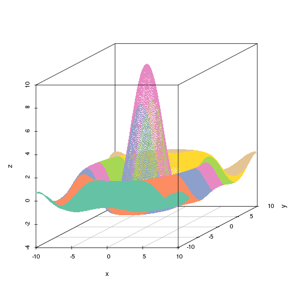

## Package description

`SOMbrero`, which means 'Self Organizing Maps Bound to Realize Euclidean and Relational Outputs', implements several variants of the stochastic Self-Organising Maps and is able to handle numeric and non numeric data sets.

See `help(SOMbrero)` for further details.

### Numeric SOM

The numeric SOM is illustrated on the well-known `iris` data set. This data describe iris flowers with 4 numeric variables (`Sepal.Length`, `Sepal.Width`, `Petal.Length` and `Petal.Width`) and a fifth variable (not used to train the SOM) is the flower's species. This example is treated in the numeric SOM guide.

### Contingency tables

The SOM algorithm provided by the package `SOMbrero` can also handle some non-numeric data. First, data described by contingency tables, which can be processed using the 'korresp' algorithm (see Cottrell et al., 1993). This case is illustrated on the `presidentielles2002` data set which contains, for each of the French administrative departments (row variables) and each of the candidates (column variables), the number of votes in the first round of the 2002 presidential election. This example can be found in the korresp user guide.

### Dissimilarity matrices

Data described by a dissimilarity matrix can also be processed by `SOMbrero` as described in Olteanu et al., 2012. This case is illustrated on a data set extracted from the novel `Les Miserables`, written by the French author Victor Hugo and published in the 19th century. This data set provides a dissimilarity matrix between the characters of the novel, based on the length of shortest paths in a network defined from the novel. This example is provided in the relational user guide.

For those who have an R developer soul, and who want to help improve this package, the following picture provides an overview the current arborescence of the package:

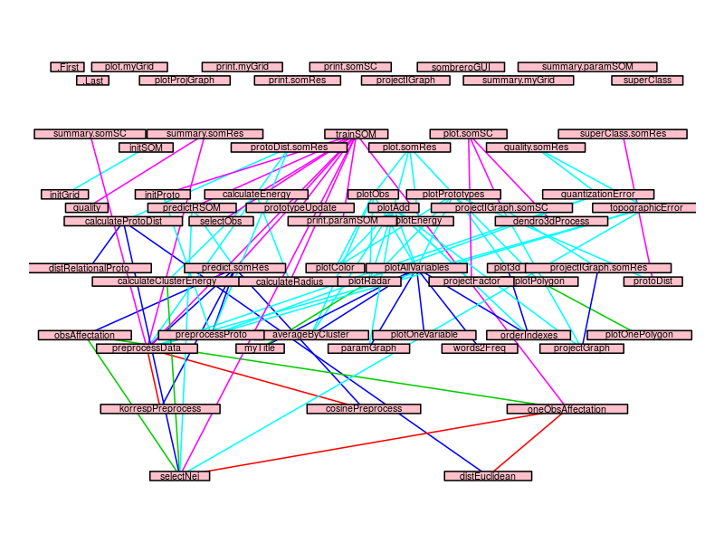